# TADs_primer

Here I follow Jacob's protocols and advices and try to observe trends and obtain preliminary conclussions about what makes a sequence a TAD.

*input* is composed of 30-mers from a sorted library ('ARG3'), splited into ~20000 positives and ~20000 negatives.  
**GOAL**: Undestand how composition of aminoacids and/or other calculated or predicted physico-chemical properties of 30mers contribute to define a Transcription Activator Domain or TAD (positives in our data-set - negatives are non-TADs)

## Index

- Amino-acid composition
  - Amino-acid frequencies
  - linear combination of single aa-freq
  - linear combination of 2-mers
  - gradient boosting models
  - position preference
  - deep learning models
    - dense
    - convolutional
    - conv+recurrent
- physical properties of amino-acids

```python
%pylab inline
import seaborn
import scipy, sklearn
import os,sys
from univariate_rocs import *
import warnings
warnings.filterwarnings('ignore')


for module in ['numpy','scipy','pd','sklearn','matplotlib','seaborn']:
    print(module + ': ' + eval(module).__version__)
```

```
================================================================================
hydroph_df: hydrophobicities per nt
iupred_short, iupred_short: predicted disorder per nt
================================================================================
================================================================================
 Calculate scores based on mean of bins for each FACS sorting
 bins info used in this script should be found in bins_info.py
================================================================================

17009 positives and 17306 negatives makes a 1.0174613439943558 ratio of negat/posit
numpy: 1.14.3
scipy: 1.1.0
pd: 0.23.0
sklearn: 0.19.1
matplotlib: 2.2.2
seaborn: 0.8.1
```

### Amino-acid composition

The first task is to predict the score (regression) or the label (classification) from the sequence of amino-acid. Score values can take ANY positive value or zero and labels are 1 (positive or TAD) and 0 (negative, no TAD). I already now that there is no overlapping between positives and negatives since I splitted them from a bigger set of sequences.

```python
# this is to print bold
start, end = "\033[1m", "\033[0;0m"

print(y_tad_regress.sample(2))
print('\n')
print(y_tad_classif.sample(2))
print('\n{} samples in the data-set used for regression analysis'.format(y_tad_regress.shape[0]))
print('The index are the sequences.\nFor'+start+'regression'+end+' there is a score and'+ \
      ' for '+start+'classification'+end+' there are labels (1|0)')
```

```
ESDEGRLFGAYNPDMDVPIMVSLVFDGYVC    11.082143
ANWAEWSYACWSLRATTSPYYIWDFDNNSG     8.438150
Name: scores, dtype: float64


AFVVNSRNVASQMVATEEVEVDVVYVGKAF    0.0
GRVTQTAPFCGNHIGSQGIRCIYPVASSRK    0.0
Name: TAD, dtype: float64

62395 samples in the data-set used for regression analysis
The index are the sequences.
Forregression there is a score and for classification there are labels (1|0)
```

### Using amino-acid frequencies

```python
# make sure that all seqs are 30aa long
nN = set([len(i) for i in negatives])
pN = set([len(i) for i in positives])
print(f'{nN} and {pN} uniq lengths for negatives and positives sets')
```

```
{30} and {30} uniq lengths for negatives and positives sets
```

```python
# y_tad_regress comes from univariate_rocs (from which I imported everything in the very first cell) and
# it's assumed to be correct here.
data = pd.DataFrame(y_tad_regress)

# list of one-letter aa
aa = ['R','H','K','D','E','S','T','N','Q','A','V','L','I','M','F' ,'Y', 'W', 'C','G','P']
for i in aa:
    data[i] = [seq.count(i) / 30. for seq in data.index]

# labels instead of scores for classification (the set is smaller, ~40000)
data_classif = pd.concat([data.drop('scores', axis=1), y_tad_classif], axis=1).dropna()


print('regression set: {}\n\nclassification set: {}'.format(data.shape,
                                                          data_classif.shape))

print('positives: {}'.format(data_classif[data_classif.TAD==1].shape[0]))
print('negatives: {}'.format(data_classif[data_classif.TAD==0].shape[0]))


data.iloc[:5,:5] # Printing part of the columns is more clear to me...
```

```
regression set: (62395, 21)

classification set: (34315, 21)
positives: 17009
negatives: 17306
```

|  | scores | R | H | K | D |
| --- | --- | --- | --- | --- | --- |
| AAAEELARLIDSMSLTWNVENSYFISGLVV | 13.155953 | 0.033333 | 0.000000 | 0.000000 | 0.033333 |
| AAALSITWSDKRSTGVRSIVHALSGYTYRE | 8.605204 | 0.100000 | 0.033333 | 0.033333 | 0.033333 |
| AAANGGMAGIKLGYEAFCNLADLDLFAHYI | 12.005210 | 0.000000 | 0.033333 | 0.033333 | 0.066667 |
| AAATCDAGLKSVLCIFCTYSLASLCRHSVT | 9.450931 | 0.033333 | 0.033333 | 0.033333 | 0.033333 |
| AAAWADVEEIGLDQLMYGTYFELDLVAVDI | 14.073415 | 0.000000 | 0.000000 | 0.000000 | 0.133333 |

Split data (0.8, 0.1, 0.1), as 4,000 samples should give us a fairly good estimate of the error (Jacob's suggestion).

```python
# Since I will do the same for regression and classification, I make it a function
def split_data(data, selection=aa, column_label_score_NAME='scores', seed=0):
    train, test = (np.array([0.8, 0.1]) * data.shape[0]).astype(int)

    X, y = data[selection].values, data[column_label_score_NAME].values

    np.random.seed = seed
    idx = np.arange(data.shape[0])
    np.random.shuffle(idx)

    X, y = X[idx], y[idx]

    Xtrain, ytrain = X[:train], y[:train]
    Xtest, ytest = X[train:-test], y[train:-test]
    Xvalid, yvalid = X[-test:], y[-test:]

    return(Xtrain, ytrain, Xtest, ytest, Xvalid, yvalid)

# create two sets of train, test, validation, one for regression and one for classification.
# These are lists that consists of 6 elements (3 sets of X,y): (X,y train), (X,y test) and (X,y validation)
# e.g. regression[0] = X_train, regression[5]= y_validation
regression = split_data(data, aa, 'scores')
classification = split_data(data_classif, aa, 'TAD')
```

As a base line to ensure that our model will be learning a useful combination of the features, we are going to evalute **spearman correlation** on **regression** models and **auc-roc** in **classification** models.

```python
from scipy.stats import spearmanr

#regression
print('\nHow much do amino-acid frequencies correlate with the scores\n'+'='*60+'\n')
print(start+'regression'+end)

corrs = np.array([spearmanr(regression[4][:,i], regression[5]) for i in range(len(aa))])
print(pd.DataFrame(corrs, index=aa, columns=['r','p_value']).sort_values('r', ascending=False))

def roc_curve(X,y):
    # make sure X and y are numpy arrays
    X,y = np.array(X), np.array(y)
    # thresholds to use for defining fpr and tpr
    scale = np.linspace(X.min(), X.max(), 50)
    # define fpr and tpr functions to use with different thresholds
    def tpr(y_hat, y):
        a,b = set(np.hstack(np.where(y==1))), set(np.hstack(np.where(y_hat==1)))
        return(len(a & b) / len(a))
    def fpr(y_hat, y):
        a,b = set(np.hstack(np.where(y==0))), set(np.hstack(np.where(y_hat==1)))
        return(len(a & b) / len(a))
    # Core of the function where TPR and FPR are calculated
    TPR, FPR = np.zeros(50), np.zeros(50)
    for n,s in enumerate(scale):
        # threshold of variable defines what is + and -
        y_hat = np.array([1 if x>=s else 0 for x in X])
        TPR[n] = tpr(y_hat, y)
        FPR[n] = fpr(y_hat, y)
    # the resulting array will contain thresholds, fpr and tpr
    roc = np.vstack([scale, FPR, TPR])
    return(roc)


from sklearn.metrics import auc

print('\n\nHow much do amino-acid frequencies correlate with the labels')
print(start+'\nclassification'+end+' (auc_roc)')
#classification
clas = {}
for i in range(len(aa)):
    Xvalid, yvalid = classification[4], classification[5]
    _, fpr, tpr = roc_curve(Xvalid[:,i], yvalid)
    clas[aa[i]] = np.round(auc(fpr, tpr),2)
    #print('{} {:.2f}'.format(aa[i], auc(fpr, tpr))) #aucspearmanr(Xvalid[:,i], yvalid))
sorted(clas.items(), key = lambda x: x[1])
```

```
How much do amino-acid frequencies correlate with the scores
============================================================

regression
          r        p_value
D  0.417792  3.827171e-262
E  0.349138  2.551603e-178
F  0.243505   6.791910e-85
V  0.186887   3.822245e-50
I  0.144795   1.392458e-30
L  0.127239   6.160254e-24
Y  0.033919   7.374703e-03
M  0.027072   3.249434e-02
N  0.016699   1.872335e-01
W  0.016495   1.926575e-01
G -0.041060   1.178885e-03
A -0.093078   1.751472e-13
C -0.129959   6.566409e-25
Q -0.136027   3.738042e-27
K -0.153532   3.224657e-34
T -0.190004   8.417547e-52
S -0.231086   2.058054e-76
H -0.238521   1.973074e-81
P -0.256125   5.032168e-94
R -0.413029  1.161577e-255


How much do amino-acid frequencies correlate with the labels

classification (auc_roc)
```

```
[('R', 0.19),
 ('P', 0.31),
 ('S', 0.33),
 ('H', 0.34),
 ('T', 0.35),
 ('C', 0.39),
 ('Q', 0.42),
 ('K', 0.43),
 ('A', 0.43),
 ('G', 0.47),
 ('N', 0.51),
 ('Y', 0.51),
 ('W', 0.53),
 ('M', 0.55),
 ('L', 0.59),
 ('I', 0.61),
 ('V', 0.64),
 ('F', 0.67),
 ('E', 0.77),
 ('D', 0.81)]
```

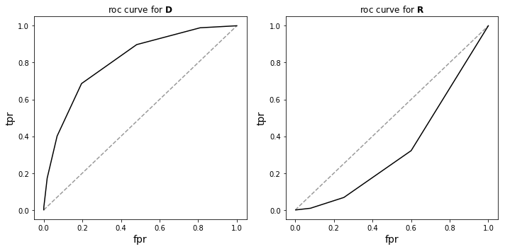

```python
# i is the index of the amino-acid in aa (D=3 and R=1)
def single(i):
    Xvalid, yvalid = classification[4], classification[5]
    _, fpr, tpr = roc_curve(Xvalid[:,i], yvalid)
    # plot the results
    plt.plot(fpr, tpr, c='k'); plt.plot([0,1], [0,1], ls='--', c='k', alpha=0.4)
    plt.xlabel("fpr", fontsize=14); plt.ylabel("tpr", fontsize=14)

plt.figure(figsize=(10,5))
plt.subplot(121); single(3); plt.title(r'roc curve for $\bf{{{D}}}$')
plt.subplot(122); single(1); plt.title(r'roc curve for $\bf{{{R}}}$')
plt.tight_layout()
```

As previously observed, "R" (anti) "D", and "E" have the highest correlations with the score. Just to remind us, these sequences are the centroids of a clustering done using usearch, allowing up to 6 missmatches per sequence. We should not have duplicates or sequences derived from other sequences from the library in this data-sets. Classification has a smaller and more polarized dataset and I expected to see higher correlations.

### Linear combination of amino-acid frequencies

```python
from sklearn.linear_model import RidgeCV

# regression
model = RidgeCV(alphas=10. ** np.arange(-2,2,.1))  # 40 tests
model.fit(regression[0], regression[1])
y_hat = model.predict(regression[4])
r, p = spearmanr(y_hat, regression[5])
print(start+'linear regression: '+end+'r = {:.2f}, (p_value={:.2f})'.format(r,p))

from sklearn.linear_model import LogisticRegressionCV

# classification
model = LogisticRegressionCV(Cs=np.linspace(1e-4,1e-2,40))
model.fit(classification[0], classification[1])
y_hat = model.predict(classification[4])
print('\n'+start+'Classificaton:'+end+' accuracy = {:.3f}'.format
    (model.score(classification[4], classification[5])))
```

```
linear regression: r = 0.67, (p_value=0.00)

Classificaton: accuracy = 0.861
```

Linear combination is performing better than single frequencies in both, regression and classificatoin analysis. These values are about the same if I use test instead of validation, this is good...

### Using frequencies of 2-mers

```python
# Taken literally from Jacob's notebook. I can't be more clear nor shorter!
import itertools

# list all "k"-mers that exist in the sequence "seq"
def kmerize(seq, k):
    return ' '.join(seq[i:i+k] for i in range(len(seq) -k +1))

# generate all possible k-mers from "aa" list
def kmers(k):
    return [''.join(kmers) for kmers in itertools.product(aa, repeat=k)]

# generate one column for each of all possible kmers in data (k=2 here)
for kmer in kmers(2):
    data[kmer] = [kmerize(seq, 2).count(kmer) / 29. for seq  in data.index]
```

I have to split the 2-mers data again and I should use the same split that I've used for the single aa frequencies data-set.  
with 29 combinations per sequence and 400 possible combinations, finding a correlation between frequencies and score might not be a good idea.  
Can a linear combination of 2-mers frequencies predict the scores or labels better than single amino-acid frequencies? Using Lasso (L1 regularization), the weight of many 2-mers will be set to 0 and it will be easier to find the 2-mers with highest weights in the linear combination optimized to predict the scores or labels

```python
### redefine the data with the 2-mers ###

# labels instead of scores for classification (the set is smaller)
data_classif = pd.concat([data[kmers(2)], y_tad_classif], axis=1).dropna()

regression = split_data(data = pd.concat([data[kmers(2)], data.loc[:,'scores']], axis=1),
                        selection=kmers(2),
                        column_label_score_NAME='scores')

classification = split_data(data_classif, kmers(2), 'TAD')
```

```python
# regression
model = RidgeCV(alphas=10. **(np.arange(-2,2,.1)))
model.fit(regression[0], regression[1])

y_hat = model.predict(regression[4])
print(start+'regression'+end+' using 2-mers and L2 regularization \n{}'.format(spearmanr(y_hat, regression[5])))

# classification
model = LogisticRegressionCV(Cs=np.linspace(1e-4,1e-1,40))
model.fit(classification[0], classification[1])
y_hat = model.predict(classification[4])
print(start+'classification'+end+' using 2-mers\naccuracy = {:.3f}'.format(model.score(classification[4], classification[5])))
```

```
regression using 2-mers and L2 regularization
SpearmanrResult(correlation=0.6706904562524169, pvalue=0.0)
classification using 2-mers
accuracy = 0.859
```

There is no improvement compared to the combination of single amino-acid freqencies.

I can:

- Try with 3-mers
- going into a more complex model using 1- and 2-mers?

**OBSERVATION**: Johannes Soeding already commented on the possibility of having 2-mers that, based on their id, quantity and distribution in a particular sequence, could make that sequence activate transcription or not. These 2-mers would constitute (alone, in tandem or at some distance) signals that would lead to the peptide being part of a luquid-liquid separated phase).

Instead of going to longer k-mers, I will try with L1 regularization regression model (following Jacob's procedures)

```python
from sklearn.linear_model import LassoCV

model = LassoCV(alphas=10. ** np.arange(-10,2,.1))
model.fit(regression[0], regression[1])

y_hat = model.predict(regression[4])

print(spearmanr(y_hat, regression[5]))
```

```
SpearmanrResult(correlation=0.6703597447900407, pvalue=0.0)
```

check what happends and will inspect the model, plotting MSE using different $\lambda$s

```
7.943282347242496e-06
```

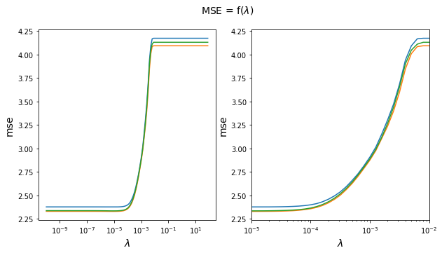

```python
plt.figure(figsize=(10,5))
plt.subplot(121)
plt.plot(model.alphas_, model.mse_path_)
plt.xscale("log")
plt.xlabel("$\lambda$", fontsize=14)
plt.ylabel('mse', fontsize=14)
plt.suptitle("MSE = f($\lambda$)", fontsize=14)

plt.subplot(122)
plt.plot(model.alphas_, model.mse_path_)
plt.xscale("log")
plt.xlabel("$\lambda$", fontsize=14)
plt.ylabel('mse', fontsize=14)
plt.xlim(10e-6,0.01)


print(model.alpha_)
```

Three lines from a 3-fold CV. low $\alpha$ => no regularization., high $\alpha$ => underfiting due to too strong regularization. There is no need for regularization in this model.

We know that D and E (also F,V,I) are highly correlated with a sequence being a TAD and R is highly anti-correlated. Do these amino-acids correlate with TAD with any surrounding amino-acid or are there combinations that contribute more to the TAD.

How many coefficients are 0?

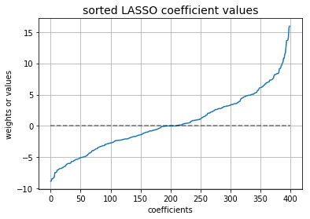

```python
coefs = np.sort(model.coef_)

plt.plot(coefs)
plt.ylabel('weights or values')
plt.xlabel('coefficients')
plt.plot((0,400),(0,0), ls='--', c='k', alpha=0.5)
plt.title("sorted LASSO coefficient values", fontsize=14)
plt.grid()
```

Would that mean that all di-peptides are informative in one way or another? What are these variables above ~5 that are strongly correlated? Are all EX,DX and some FX?

```python
# I call the weights heavy and light. Will search for heavy and light di-peptides from the LASSO model.
heavy = np.hstack(np.where(model.coef_>5))
light = np.hstack(np.where(model.coef_<-7.5))

print('di-peptides highly '+start+'correlated'+end+' with TAD activity\n')
print(np.array([kmers(2)[i] for i in heavy])); print('\n')
print('di-peptides highly '+start+'anti-correlated'+end+' with TAD activity\n')
print(np.array([kmers(2)[i] for i in light]))
```

```
di-peptides highly correlated with TAD activity

['DD' 'DE' 'DA' 'DV' 'DL' 'DI' 'DM' 'DF' 'DY' 'DW' 'DC' 'ED' 'EE' 'EA'
 'EV' 'EL' 'EI' 'EM' 'EF' 'EY' 'EW' 'EC' 'SF' 'TF' 'NF' 'NW' 'QW' 'VF'
 'LF' 'LW' 'IF' 'ML' 'MF' 'MW' 'FD' 'FL' 'FI' 'FM' 'FF' 'FW' 'YD' 'YE'
 'YL' 'YI' 'YM' 'YF' 'YW' 'WD' 'WE' 'WA' 'WV' 'WL' 'WI' 'WM' 'WF' 'WY'
 'WW' 'WC' 'CF' 'CW' 'CC' 'GF' 'PF' 'PW']


di-peptides highly anti-correlated with TAD activity

['RQ' 'KR' 'QH' 'QK' 'AR' 'VK' 'IR']
```

This might be more interpretable with a heatmap including all combinations of aa, where weights are colors. Each weight is the importance of the di-peptide that it multiplies in the linear combination of all 400 di-peptides. The stronger the weight, the more correlated is the di-peptide with the score. Vice-versa for negative weights, large values indicate strong anti-correlation.

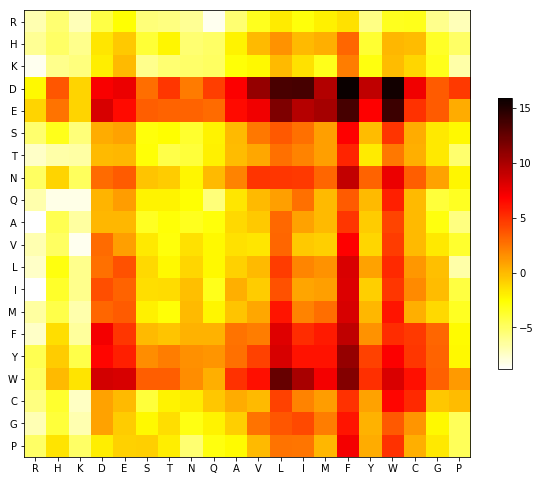

```python
# Will fill this matrix with LASSO weights from all combinations
matrix = np.zeros(shape=(20,20))
# fx to get the 2d coordinate of that combination in the LASSO's weights matrix
position = lambda km: [aa.index(j) for j in km]

for n,i in enumerate(kmers(2)):
    a,b = position(i)
    matrix[a][b] = model.coef_[n]

plt.figure(figsize=(10,10))
ax = plt.subplot(111)
im = ax.imshow(matrix, cmap='hot_r')
plt.colorbar(im, shrink=0.5)
ax.set_xticks(np.arange(20));
ax.set_yticks(np.arange(20));
ax.set_xticklabels(aa); ax.set_yticklabels(aa);
```

Negatively charged residues were described by Ptashne, Struhl and others to be an important characteristic of TADs. Steve's PNAS from 2014 shows that W,L and F had a strong influence in a TAD motif. Here we have both concepts summarized in di-peptides...

**TODO**:

- Try 3-mers
- Do same procedure for all predicted and calculated physico-chemical properties

For now I will try gradient boosting to look for non-linear and more complex interactions between di-peptides.

First, out of the box and then I can optimize the algorithm tunning the hyper-parameters

## Gradient boosting models

```python
import xgboost

# regression
model = xgboost.XGBRegressor(n_jobs=-1)
model.fit(regression[0], regression[1])

y_hat = model.predict(regression[4])
print(start+'regression'+end)
print(spearmanr(y_hat, regression[5]))

# classification
model = xgboost.XGBRegressor(n_jobs=-1, binary=logistic)
model.fit(classification[0], classification[1])

y_hat = model.predict(classification[4])
print('\n'+start+'classification'+end)
print(spearmanr(y_hat, classification[5]))
```

```
regression
SpearmanrResult(correlation=0.6015456084138642, pvalue=0.0)

classification
SpearmanrResult(correlation=0.7503989906423564, pvalue=0.0)
```

Not good. I would expect that it behaves at least as good as linear regression. I will follow Jacob's procedure to tune the parameters.

```python
'''I AM RUNNING IT IN 4 CPUS FROM THE CAMPUS PARTITION OF GIZMO SERVER'''

# cost function
#spearman = lambda a,b: spearmanr(a,b)[0]
def spearman(x, y): return spearmanr(x, y)[0]

# dictionary of parameters # this is just one combination from the multiple that I am trying at gizmo
params = {
    'n_estimators': [500], # how many trees? -> the more trees, the less overfitting
    'max_depth': [5], # max depth of each tree. Keep it small to avoid overfitting
    'learning_rate':[0.5], # prevents overfitting (at expense)
    'gamma': [0.3], # minimum loss reduction required for a further partition on a leaf node of the tree. large is good
    'reg_lambda': 10. **-2, # L2 regularization
    'subsample': [0.6] # sample training data prior to growing the trees. Avoids overfitting
}

# These makes 9072 combinations. I can randomly sample a fraction of them and test their performance.
# I will sample 1000 models and will choose the best from a 3-fold cross validation.

# from sklearn.model_selection import GridSearchCV can't control the number of models to test from all combinations?
from sklearn.model_selection import RandomizedSearchCV
from sklearn.metrics import make_scorer

model = xgboost.XGBRegressor(n_estimators=1000,
                             max_depth=3,
                             learning_rate=0.03,
                             gamma=0.3,
                             reg_lambda=10.**-0.5,
                             subsample=0.6,
                             binary='logistic')

# regression
model.fit(classification[0], classification[1]);
```

```python
y_hat = model.predict(classification[4])
acc = np.sum(np.round(y_hat,0)==classification[5]) *1.0 / y_hat.shape[0]
print(start+'\nGradient boosting'+end+' with optimized hyperparameters\n')
print(start+'regression'+end+' r=0.69')
print(start+'classification'+end+' acc= {}\n'.format(np.round(acc,3)))
```

[output not shown]

### Is there any preference with respect to "N" terminal or "nearby" the DNA binding domain?

Even though we assume that IF there is a motif, it might be "anywhere" in the sequence and there might be "tandem" or "distant" interactions that are major contributors to the TAD, I might see if there is any hint about position preferences within the sequence.

```python
def one_hot_encode(seq):
    X = np.zeros(shape=(len(seq),len(aa)))
    try:
        for n,i in enumerate(seq): X[n, aa.index(i)] = 1
        return X
    except exception as e:
        print('exception {} encountered'.format(e))

print(data.index[0])
print(one_hot_encode(data.index[0]).flatten())
```

```
AAAEELARLIDSMSLTWNVENSYFISGLVV
[0. 0. 0. 0. 0. 0. 0. 0. 0. 1. 0. 0. 0. 0. 0. 0. 0. 0. 0. 0. 0. 0. 0. 0.
 0. 0. 0. 0. 0. 1. 0. 0. 0. 0. 0. 0. 0. 0. 0. 0. 0. 0. 0. 0. 0. 0. 0. 0.
 0. 1. 0. 0. 0. 0. 0. 0. 0. 0. 0. 0. 0. 0. 0. 0. 1. 0. 0. 0. 0. 0. 0. 0.
 0. 0. 0. 0. 0. 0. 0. 0. 0. 0. 0. 0. 1. 0. 0. 0. 0. 0. 0. 0. 0. 0. 0. 0.
 0. 0. 0. 0. 0. 0. 0. 0. 0. 0. 0. 0. 0. 0. 0. 1. 0. 0. 0. 0. 0. 0. 0. 0.
 0. 0. 0. 0. 0. 0. 0. 0. 0. 1. 0. 0. 0. 0. 0. 0. 0. 0. 0. 0. 1. 0. 0. 0.
 0. 0. 0. 0. 0. 0. 0. 0. 0. 0. 0. 0. 0. 0. 0. 0. 0. 0. 0. 0. 0. 0. 0. 0.
 0. 0. 0. 1. 0. 0. 0. 0. 0. 0. 0. 0. 0. 0. 0. 0. 0. 0. 0. 0. 0. 0. 0. 0.
 1. 0. 0. 0. 0. 0. 0. 0. 0. 0. 0. 1. 0. 0. 0. 0. 0. 0. 0. 0. 0. 0. 0. 0.
 0. 0. 0. 0. 0. 0. 0. 0. 0. 1. 0. 0. 0. 0. 0. 0. 0. 0. 0. 0. 0. 0. 0. 0.
 0. 0. 0. 0. 0. 0. 0. 0. 0. 0. 0. 0. 0. 1. 0. 0. 0. 0. 0. 0. 0. 0. 0. 0.
 0. 1. 0. 0. 0. 0. 0. 0. 0. 0. 0. 0. 0. 0. 0. 0. 0. 0. 0. 0. 0. 0. 0. 0.
 0. 0. 0. 1. 0. 0. 0. 0. 0. 0. 0. 0. 0. 0. 0. 0. 0. 0. 1. 0. 0. 0. 0. 0.
 0. 0. 0. 0. 0. 0. 0. 0. 0. 0. 0. 0. 0. 0. 0. 0. 0. 0. 0. 0. 0. 0. 0. 0.
 1. 0. 0. 0. 0. 0. 0. 0. 0. 0. 0. 1. 0. 0. 0. 0. 0. 0. 0. 0. 0. 0. 0. 0.
 0. 0. 0. 0. 0. 0. 0. 0. 0. 0. 1. 0. 0. 0. 0. 0. 0. 0. 0. 0. 0. 0. 0. 0.
 1. 0. 0. 0. 0. 0. 0. 0. 0. 0. 0. 0. 0. 0. 0. 0. 0. 0. 0. 0. 0. 0. 0. 1.
 0. 0. 0. 0. 0. 0. 0. 0. 0. 0. 0. 0. 0. 0. 0. 0. 0. 1. 0. 0. 0. 0. 0. 0.
 0. 0. 0. 0. 0. 0. 0. 0. 0. 0. 0. 0. 0. 0. 0. 0. 0. 0. 0. 0. 0. 0. 0. 1.
 0. 0. 0. 0. 0. 0. 0. 0. 0. 0. 0. 0. 0. 0. 0. 0. 0. 0. 1. 0. 0. 0. 0. 0.
 0. 0. 0. 0. 0. 0. 0. 0. 0. 0. 0. 0. 1. 0. 0. 0. 0. 0. 0. 0. 0. 0. 0. 0.
 0. 1. 0. 0. 0. 0. 0. 0. 0. 0. 0. 0. 0. 0. 0. 0. 0. 0. 0. 0. 0. 0. 0. 0.
 0. 0. 0. 0. 0. 0. 0. 0. 0. 0. 1. 0. 0. 0. 0. 0. 0. 0. 0. 0. 0. 0. 0. 1.
 0. 0. 0. 0. 0. 0. 0. 0. 0. 0. 0. 0. 0. 0. 0. 0. 0. 0. 1. 0. 0. 0. 0. 0.
 0. 0. 0. 0. 0. 0. 0. 0. 0. 0. 0. 0. 0. 0. 1. 0. 0. 0. 0. 0. 0. 0. 0. 0.]
```

I will start with single amino-acids and might try to repeat the procedure for di-peptides.peptides

```python
singles = data.index
singles = np.array([one_hot_encode(i) for i in singles]).reshape(singles.shape[0],600)
print(singles.shape)

ohe_data = pd.DataFrame(singles, index=data.index)
ohe_data_regress = pd.concat([ohe_data, data.scores],axis=1)
ohe_data_classif = pd.concat([ohe_data, data_classif.TAD],axis=1)
```

```
(62395, 600)
```

```python
# repeat the split as I did it previously
regression = split_data(ohe_data_regress, np.arange(0,600), 'scores')
classification = split_data(ohe_data_classif, np.arange(0,600), 'TAD')
ohe_data_regress.head(4)
```

|  | 0 | 1 | 2 | 3 | 4 | 5 | 6 | 7 | 8 | 9 | ... | 591 | 592 | 593 | 594 | 595 | 596 | 597 | 598 | 599 | scores |
| --- | --- | --- | --- | --- | --- | --- | --- | --- | --- | --- | --- | --- | --- | --- | --- | --- | --- | --- | --- | --- | --- |
| AAAEELARLIDSMSLTWNVENSYFISGLVV | 0.0 | 0.0 | 0.0 | 0.0 | 0.0 | 0.0 | 0.0 | 0.0 | 0.0 | 1.0 | ... | 0.0 | 0.0 | 0.0 | 0.0 | 0.0 | 0.0 | 0.0 | 0.0 | 0.0 | 13.155953 |
| AAALSITWSDKRSTGVRSIVHALSGYTYRE | 0.0 | 0.0 | 0.0 | 0.0 | 0.0 | 0.0 | 0.0 | 0.0 | 0.0 | 1.0 | ... | 0.0 | 0.0 | 0.0 | 0.0 | 0.0 | 0.0 | 0.0 | 0.0 | 0.0 | 8.605204 |
| AAANGGMAGIKLGYEAFCNLADLDLFAHYI | 0.0 | 0.0 | 0.0 | 0.0 | 0.0 | 0.0 | 0.0 | 0.0 | 0.0 | 1.0 | ... | 0.0 | 1.0 | 0.0 | 0.0 | 0.0 | 0.0 | 0.0 | 0.0 | 0.0 | 12.005210 |
| AAATCDAGLKSVLCIFCTYSLASLCRHSVT | 0.0 | 0.0 | 0.0 | 0.0 | 0.0 | 0.0 | 0.0 | 0.0 | 0.0 | 1.0 | ... | 0.0 | 0.0 | 0.0 | 0.0 | 0.0 | 0.0 | 0.0 | 0.0 | 0.0 | 9.450931 |

4 rows × 601 columns

I have 20 amino-acids x 30 positions and will corelate each of these 600 columns with the score. I will plot a histogram to see how are these values distributed but will also plot a 2D heatmap to potentially recognize combinations (aa-position) that show better correlation with score than the average.

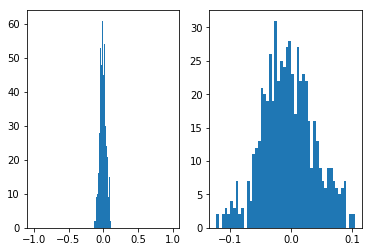

```python
# regression
corrs = np.zeros(600)
x_train, y_train = regression[0], regression[1]
x_valid , y_valid = regression[4], regression[5]

for n,r in enumerate(x_valid.T):
    corrs[n] = spearmanr(r, y_valid)[0]

# plot histogram
plt.subplot(121)
plt.hist(corrs, bins=np.arange(-1,1,0.01));
plt.subplot(122)
plt.hist(corrs, bins=50);
```

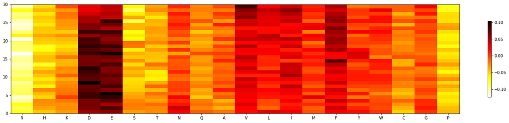

```python
# plot heatmap
f, ax = plt.subplots(figsize=(25,5))
im = ax.pcolor(corrs.reshape(30,20), cmap="hot_r")
ax.set_xticks(np.arange(0.5, 20.5))
ax.set_xticklabels(aa)
plt.colorbar(im, shrink=0.7)
```

**All values are below 0.15 or above -0.15 so conclusions from this plot might be irrelevant**  
My observation is that the correlation of "D" and "E" as well as the anticorrelation of "R" seem to decrease towards the DNA Binding Domain or DBD (it goes N$_t$--TAD-DBD--C$_t$).

On the other hand, V,L and F seem to correlate better when they are present close to the DBD.

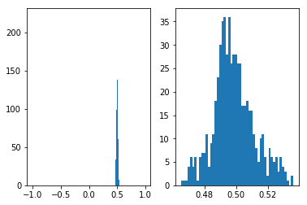

```python
# classification
corrs = np.zeros(600)
x_train, y_train = classification[0], classification[1]
x_valid , y_valid = classification[4], classification[5]

for n,r in enumerate(x_valid.T):
    _, fpr, tpr = roc_curve(r, y_valid)
    corrs[n] = auc(fpr, tpr)

# plot histogram
plt.subplot(121)
plt.hist(corrs, bins=np.arange(-1,1,0.01));
plt.subplot(122)
plt.hist(corrs, bins=50);
```

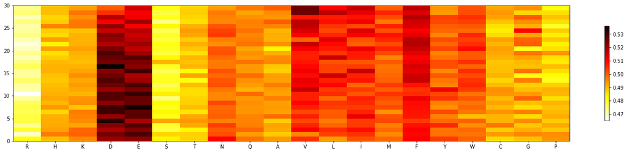

```python
# plot heatmap
f, ax = plt.subplots(figsize=(25,5))
im = ax.pcolor(corrs.reshape(30,20), cmap="hot_r")
ax.set_xticks(np.arange(0.5, 20.5))
ax.set_xticklabels(aa)
plt.colorbar(im, shrink=0.7)
```

**Why are all values positive?**

```python
# generate one column for each of all possible 2-mers for all 30 positions in data
def one_hot_encode_2mers(seq):
    X = np.zeros(shape=(len(seq),len(aa)**2))
    try:
        for n in range(len(seq)-1):
            _1, _2 = seq[n], seq[n+1]
            X[aa.index(_1), aa.index(_2)] = 1
        return X
    except exception as e:
        print('exception {} encountered'.format(e))

print(data.index[0])
print(one_hot_encode_2mers(data.index[0]).flatten().shape)
```

```
AAAEELARLIDSMSLTWNVENSYFISGLVV
(12000,)
```

```python
doubles = data.index
doubles = np.array([one_hot_encode_2mers(i) for i in doubles]).reshape(doubles.shape[0],12000)
print(doubles.shape)

#cols = np.concatenate([[''.join([str(i),'_',j]) for j in kmers(2)] for i in range(30)])
ohe_data = pd.DataFrame(doubles, index=data.index)#, columns=cols)


ohe_data_regress = pd.concat([ohe_data, data.scores],axis=1)
ohe_data_classif = pd.concat([ohe_data, data_classif.TAD],axis=1)

# repeat the split as I did it previously
regression = split_data(ohe_data_regress, np.arange(0,12000), 'scores')
classification = split_data(ohe_data_classif, np.arange(0,12000), 'TAD')
ohe_data_regress.head(4)
```

```
(62395, 12000)
```

|  | 0 | 1 | 2 | 3 | 4 | 5 | 6 | 7 | 8 | 9 | ... | 11991 | 11992 | 11993 | 11994 | 11995 | 11996 | 11997 | 11998 | 11999 | scores |
| --- | --- | --- | --- | --- | --- | --- | --- | --- | --- | --- | --- | --- | --- | --- | --- | --- | --- | --- | --- | --- | --- |
| AAAEELARLIDSMSLTWNVENSYFISGLVV | 0.0 | 0.0 | 0.0 | 0.0 | 0.0 | 0.0 | 0.0 | 0.0 | 0.0 | 0.0 | ... | 0.0 | 0.0 | 0.0 | 0.0 | 0.0 | 0.0 | 0.0 | 0.0 | 0.0 | 13.155953 |
| AAALSITWSDKRSTGVRSIVHALSGYTYRE | 0.0 | 0.0 | 0.0 | 0.0 | 1.0 | 1.0 | 0.0 | 0.0 | 0.0 | 0.0 | ... | 0.0 | 0.0 | 0.0 | 0.0 | 0.0 | 0.0 | 0.0 | 0.0 | 0.0 | 8.605204 |
| AAANGGMAGIKLGYEAFCNLADLDLFAHYI | 0.0 | 0.0 | 0.0 | 0.0 | 0.0 | 0.0 | 0.0 | 0.0 | 0.0 | 0.0 | ... | 0.0 | 0.0 | 0.0 | 0.0 | 0.0 | 0.0 | 0.0 | 0.0 | 0.0 | 12.005210 |
| AAATCDAGLKSVLCIFCTYSLASLCRHSVT | 0.0 | 1.0 | 0.0 | 0.0 | 0.0 | 0.0 | 0.0 | 0.0 | 0.0 | 0.0 | ... | 0.0 | 0.0 | 0.0 | 0.0 | 0.0 | 0.0 | 0.0 | 0.0 | 0.0 | 9.450931 |

4 rows × 12001 columns

Too many samples with "only" zeroes (spearmanr=nan). Is it worth trying to proceed with this?

### Deep learning predictions

I will start with a Dense network which is fast to train and then I will train on the gizmo server a convolutional network and a convolutional + recurrent network with the hope to incorporate in the predictive model:

- A combination of 2-mers in defined positions or distances from each-other
- A motif Later I could dig into the models and find these features.

I will optimize the number of layers and the number of nodes per layer in a dense network (multi-layer perceptrons).

```python
from keras.models import Sequential
from keras.layers import Dense, Conv1D, Flatten, LSTM, Dropout
from keras.callbacks import EarlyStopping
from tqdm import tqdm
import keras.backend as K
```

```python
# Generate the data with one hot encoding for single positions and even though I am going to test
# convolutional networks, I will also test the 2-mers.

# produce the ohe
singles = data.index
singles = np.array([one_hot_encode(i) for i in singles]).reshape(singles.shape[0],600)
print(singles.shape)

# join ohe with scores or labels
ohe_data = pd.DataFrame(singles, index=data.index)
ohe_data_regress = pd.concat([ohe_data, data.scores],axis=1)
ohe_data_classif = pd.concat([ohe_data, data_classif.TAD],axis=1)

# split data
regression = split_data(ohe_data_regress, np.arange(0,600), 'scores')
classification = split_data(ohe_data_classif, np.arange(0,600), 'TAD')
ohe_data_regress.head(4)
```

```
(62395, 600)
```

|  | 0 | 1 | 2 | 3 | 4 | 5 | 6 | 7 | 8 | 9 | ... | 591 | 592 | 593 | 594 | 595 | 596 | 597 | 598 | 599 | scores |
| --- | --- | --- | --- | --- | --- | --- | --- | --- | --- | --- | --- | --- | --- | --- | --- | --- | --- | --- | --- | --- | --- |
| AAAEELARLIDSMSLTWNVENSYFISGLVV | 0.0 | 0.0 | 0.0 | 0.0 | 0.0 | 0.0 | 0.0 | 0.0 | 0.0 | 1.0 | ... | 0.0 | 0.0 | 0.0 | 0.0 | 0.0 | 0.0 | 0.0 | 0.0 | 0.0 | 13.155953 |
| AAALSITWSDKRSTGVRSIVHALSGYTYRE | 0.0 | 0.0 | 0.0 | 0.0 | 0.0 | 0.0 | 0.0 | 0.0 | 0.0 | 1.0 | ... | 0.0 | 0.0 | 0.0 | 0.0 | 0.0 | 0.0 | 0.0 | 0.0 | 0.0 | 8.605204 |
| AAANGGMAGIKLGYEAFCNLADLDLFAHYI | 0.0 | 0.0 | 0.0 | 0.0 | 0.0 | 0.0 | 0.0 | 0.0 | 0.0 | 1.0 | ... | 0.0 | 1.0 | 0.0 | 0.0 | 0.0 | 0.0 | 0.0 | 0.0 | 0.0 | 12.005210 |
| AAATCDAGLKSVLCIFCTYSLASLCRHSVT | 0.0 | 0.0 | 0.0 | 0.0 | 0.0 | 0.0 | 0.0 | 0.0 | 0.0 | 1.0 | ... | 0.0 | 0.0 | 0.0 | 0.0 | 0.0 | 0.0 | 0.0 | 0.0 | 0.0 | 9.450931 |

4 rows × 601 columns

#### Dense

```python
# Do this on gizmo server using multiple cpus. I don't know yet how to do it with jupyter notebook.

'''# go over the # of layers and nodes and see which is
# the # of parameters that gives the best correlation with real labels.

callback = EarlyStopping(patience=1)
num_layers, num_nodes = range(1,4), 2 ** numpy.arange(11)

corrs = []

for nlayers, nnodes in tqdm(itertools.product(num_layers, num_nodes)):
    #np.random.seed(0)

    K.clear_session()
    model = Sequential()
    model.add(Dense(nnodes, activation='relu', input_shape=(600,)))

    for i in range(nlayers-1):
        model.add(Dense(nnodes, activation='relu'))

    model.add(Dense(1))
    model.compile(optimizer='adam', loss='mse', metrics=['mse'])
    model.fit(regression[0], regression[1],
              epochs=100,
              validation_split=0.1,
              callbacks=[callback],
              verbose=0)

    y_pred = model.predict(regression[4])

    corrs.append([nlayers, nnodes, model.count_params(), spearmanr(y_pred, regression[5])])

corrs = np.array(corrs)''';
```

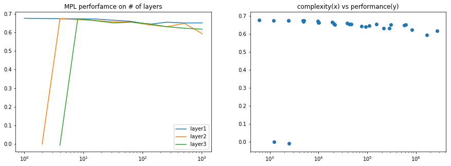

```python
deep_dense = np.load('./deep_test_dense.npy')

# plot correlations versus number of nodes (on 3 diff. models w/1-3 layers) and
# number of parameters (as a measure of the complexity of the model)

# things that were not loaded in this notebook
num_layers, num_nodes = range(1,4), 2 ** numpy.arange(11)

plt.figure(figsize=(15,5))
plt.subplot(121)
y1,y2,y3 = [deep_dense[deep_dense[:,0]==i, -1] for i in num_layers]
[plt.plot(num_nodes, y, label=label) for y,label in zip([y1,y2,y3], ['layer'+str(i) for i in range(1,4)])]
plt.legend()
plt.title('MPL perforfamce on # of layers')
plt.xscale('log')

plt.subplot(122)
plt.scatter(deep_dense[:,-2], deep_dense[:,-1])
plt.title('complexity(x) vs performance(y)')
plt.xscale('log')
```

Does it start to overfit with 10 nodes per layer?

#### Convolutional

With the convolutional models, I will optimize the number of layers, the number of filters per layer, the size of the 1D convolutions and the number of nodes in the dense layer.

```python
# will run this on gizmo...
'''# reshape the matrices for the convolutions
Xtrain, Xvalid = [regression[i].reshape(regression[i].shape[0], 30,20) for i in [0,4]]

num_conv_layers, num_conv_filters = range(1,4), 2**np.arange(7)
filter_width, num_nodes = [3,5,7,9], 2**np.arange(1,7)

callback = EarlyStopping(patience=1)
params = [num_conv_layers, num_conv_filters, filter_width, num_nodes]
corrs = []
for ncl, ncf, fw, nnodes in tqdm(itertools.product(*params)):
    K.clear_session()
    model.Sequential()
    model.add(Conv1D(ncf, fw, activation='relu', padding='same', input_shape=(30,20)))

    for l in range(ncl-1):
        model.add(Conv1D(ncf, fw, activation='relu', padding='same'))

    model.add(Flatten())
    model.add(Dense(nnodes, activation='relu'))
    model.add(Dense(1))

    model.compile(optimizer='rmsprop', loss='mse', metrics=['mse'])

    model.fit(Xtrain, regression[1], epochs=100, validation_split=0.1, callbacks=[callback], verbose=0)


    y_pred = model.predict(Xvalid)
    corr = spearmanr(y_pred, regression[5])[0]
    corrs.append([ncl, ncf, fw, nnodes, model.count_params(), corr])

corrs = np.array(corrs)'''
```

```
Text(0,0.5,'spearman r')
```

[figure not shown]

```python
deep_conv = np.load('./deep_test_conv.npy')

# plot correlations versus number of nodes (on 3 diff. models w/1-3 layers) and
# number of parameters (as a measure of the complexity of the model)

# things that were not loaded in this notebook
num_conv_layers, num_conv_filters = range(1,4), 2**np.arange(7)
filter_width, num_nodes = [3,5,7,9], 2**np.arange(1,7)

plt.figure(figsize=(10,10))

plt.subplot(221)
plt.title('number of nodes in Dense layer')
plt.scatter(deep_conv[:,-2], deep_conv[:,-1])
plt.ylabel('spearman r')
plt.xscale('log')

plt.subplot(222)
plt.title('convolution filter width')
plt.scatter(deep_conv[:,-3], deep_conv[:,-1])
plt.ylabel('spearman r')

plt.subplot(223)
plt.title('# of filters')
plt.scatter(deep_conv[:,-4], deep_conv[:,-1])
plt.ylabel('spearman r')

plt.subplot(224)
plt.title('# of convolution layers')
plt.scatter(deep_conv[:,-5], deep_conv[:,-1])
plt.ylabel('spearman r')
```

1. Adding complexity to these models doesn't help.
2. These models are not learning more than the position independent models

#### Convolutional + Recurrent

```python
## in gizmo
'''from keras layers import LSTM

num_conv_layers, num_conv_filters = range(1,4), 2**np.arange(3)
filter_width, num_nodes = [3,6,9], 2**np.arange(1,4)
lstm_units = [3,6,9]

callback = EarlyStopping(patience=1)
params = [num_conv_layers, num_conv_filters, filter_width, num_nodes, lstm_units]
corrs = []
for ncl, ncf, fw, nnodes, lstmn in tqdm(itertools.product(*params)):
    K.clear_session()
    model.Sequential()
    model.add(Conv1D(ncf, fw, activation='relu', padding='same', input_shape=(30,20)))

    for l in range(ncl-1):
        model.add(Conv1D(ncf, fw, activation='relu', padding='same'))
        model.add(LSTM(lstmn))

    model.add(Flatten())
    model.add(Dense(nnodes, activation='relu'))
    model.add(Dense(1))

    model.compile(optimizer='rmsprop', loss='mse', metrics=['mse'])

    model.fit(Xtrain, regression[1], epochs=100, validation_split=0.1, callbacks=[callback], verbose=0)


    y_pred = model.predict(Xvalid)
    corr = spearmanr(y_pred, regression[5])[0]
    corrs.append([ncl, ncf, fw, nnodes, model.count_params(), corr])

corrs = np.array(corrs)'''
```

### Following I correlate distribution of physical properties (one at a time) with score or label

I have been using iupred and psipred results that only inlcude the 30 amino-acids. I will not include these properties here. Lukasz prepared new data clustered and splitted differently. After this analysis I will continue with the new data and will run iupred and psipred including linker-sequences in the extremes of the fragments to improve the performance of the predictions of disorder and 2$^{ry}$ structure

```python
from physical_properties import properties
properties
```

|  | mass | volume1 | volume2 | hydrophobicity1 | hydrophobicity2 | pI | charge | VdW |
| --- | --- | --- | --- | --- | --- | --- | --- | --- |
| A | 71.0788 | -2.6 | 88.6 | 1.8 | 0.50 | 6.00 | 0.0 | 67 |
| R | 156.1875 | 7.9 | 173.4 | -4.5 | 1.81 | 10.76 | 1.0 | 148 |
| N | 114.1038 | 7.0 | 114.1 | -3.5 | 0.85 | 5.41 | 0.0 | 96 |
| D | 115.0886 | 11.9 | 111.1 | -3.5 | 3.64 | 2.77 | -1.0 | 91 |
| C | 103.1388 | -1.0 | 108.5 | 2.5 | -0.02 | 5.07 | 0.0 | 86 |
| E | 129.1155 | 8.5 | 138.4 | -3.5 | 3.63 | 3.22 | -1.0 | 109 |
| Q | 128.1307 | 1.3 | 143.8 | -3.5 | 0.77 | 5.65 | 0.0 | 114 |
| G | 57.0519 | 0.0 | 60.1 | -0.4 | 1.15 | 5.97 | 0.0 | 48 |
| H | 137.1411 | 3.3 | 153.2 | -3.2 | 0.11 | 7.59 | 0.5 | 118 |
| I | 113.1594 | -2.6 | 166.7 | 4.5 | -1.12 | 6.02 | 0.0 | 124 |
| L | 113.1594 | -6.2 | 166.7 | 3.8 | -1.25 | 5.98 | 0.0 | 124 |
| K | 128.1741 | 7.6 | 168.6 | -3.9 | 2.80 | 9.74 | 1.0 | 135 |
| M | 131.1926 | 0.7 | 162.9 | 1.9 | -0.67 | 5.74 | 0.0 | 124 |
| F | 147.1766 | -0.9 | 189.9 | 2.8 | -1.71 | 5.48 | 0.0 | 135 |
| P | 97.1167 | -6.2 | 112.7 | -1.6 | 0.14 | 6.30 | 0.0 | 90 |
| S | 87.0782 | 1.4 | 89.0 | -0.8 | 0.46 | 5.68 | 0.0 | 73 |
| T | 101.1051 | 0.3 | 116.1 | -0.7 | 0.25 | 5.60 | 0.0 | 93 |
| W | 186.2132 | 0.6 | 227.8 | -0.9 | -2.09 | 5.89 | 0.0 | 163 |
| Y | 163.1760 | -0.3 | 193.6 | -1.3 | -0.71 | 5.66 | 0.0 | 141 |
| V | 99.1326 | -3.6 | 140.0 | 4.2 | -0.46 | 5.96 | 0.0 | 105 |

```python
# assign properties position-wise
def assign_property2seq(property_name, seq): return [properties.loc[res,property_name] for res in seq]

for i in properties.columns:
    cols = [str(i) for i in range(30)]
    feature_regress = pd.DataFrame([assign_property2seq(i, seq) for seq in data.index],
                                   index=data.index, columns=cols)
    feature_class = pd.DataFrame([assign_property2seq(i, seq) for seq in data_classif.index],
                                 index=data_classif.index, columns=cols)

    d_regress = pd.concat([feature_regress, data['scores']], axis=1)
    d_class = pd.concat([feature_class, data_classif['TAD']], axis=1)

    regression = split_data(d_regress, cols, 'scores')
    classification = split_data(d_class, cols, 'TAD')

    # regression
    model = RidgeCV(alphas=10. ** np.arange(-2,2,.1))  # 40 tests
    model.fit(regression[0], regression[1])
    y_hat = model.predict(regression[4])
    r, p = spearmanr(y_hat, regression[5])
    print(start+'linear regression ('+i+'): '+end+'r = {:.2f}, (p_value={:.2f})'.format(r,p))

    # classification
    model = LogisticRegressionCV(Cs=np.linspace(1e-4,1e-2,40))
    model.fit(classification[0], classification[1])
    y_hat = model.predict(classification[4])
    print(start+'Classificaton ('+i+'):'+end+' accuracy = {:.3f}\n'.format
    (model.score(classification[4], classification[5])))
```

```
linear regression (mass): r = 0.07, (p_value=0.00)
Classificaton (mass): accuracy = 0.510

linear regression (volume1): r = 0.22, (p_value=0.00)
Classificaton (volume1): accuracy = 0.620

linear regression (volume2): r = 0.16, (p_value=0.00)
Classificaton (volume2): accuracy = 0.592

linear regression (hydrophobicity1): r = 0.27, (p_value=0.00)
Classificaton (hydrophobicity1): accuracy = 0.675

linear regression (hydrophobicity2): r = 0.21, (p_value=0.00)
Classificaton (hydrophobicity2): accuracy = 0.613

linear regression (pI): r = 0.61, (p_value=0.00)
Classificaton (pI): accuracy = 0.853

linear regression (charge): r = 0.62, (p_value=0.00)
Classificaton (charge): accuracy = 0.864

linear regression (VdW): r = 0.09, (p_value=0.00)
Classificaton (VdW): accuracy = 0.544
```